# Question

En un estudio realizado por Dumville et al,[^1] los investigadores presentan los resultados de un ensayo clínico en el que analizaban el uso de larvas en el tratamiento de las úlceras venosas en las piernas.

Los pacientes se asignaron a 3 grupos de intervención:

- Loose larvae (Larvas sueltas)
- Bagged larvae (Larvas empaquetadas)
- Hygrogel (Tratamiento convencional)

Las características de los participantes, según los 3 grupos y total (*overall*), se muestra en la siguiente tabla extraída del artículo:

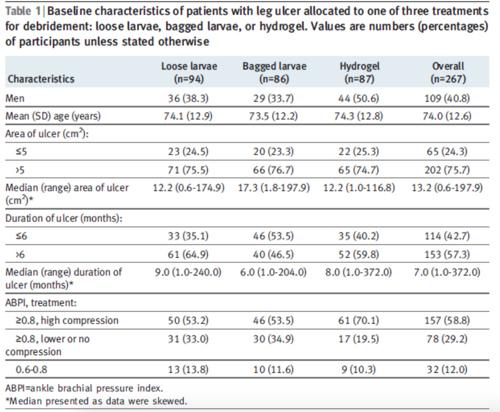

Observe que describen las siguientes características:

- Sexo (*men*)
- Edad en años (*Mean (SD) age (years)*)
- Cm² del área de la úlcera (*Area of ulcer (cm²*) en dos categorías
  - ≤ 5
  - > 5
- Cm² del área de la úlcera medido cuantitativamente (*Median (range) area of ulcer (cm²)*)
- Meses de evolución de la úlcera (*Duration of ulcer (months)*)
  - ≤ 6
  - > 6
- Meses de evolución de la úlcera medido cuantitativamentes (*Duration of ulcer (months)*)
- Tratamiento aplicado a la presión del Índice Tobillo Brazo (*ABPI, treatment*) en tres categorías:
  - Valores ≥ 0.8 tratados con alta compresión (*high compression*)
  - Valores ≥ 0.8 tratados con baja o sin compresión (*lower or no compression*)
  - Valores entre 0.6-0.8

¿Cuál de las siguientes respuestas es **FALSA**?

## Answerlist

- Los años de edad es una variable cualitativa ordinal
- Los valores de “meses de evolución de la úlcera” los presentan cualitativamente y cuantitativamente
- Cuando miden los “meses de evolución de la úlcera” como ≤6 y >6, es una variable dicotómica
- La variable que mide el sexo, es una variable dicotómica
- La variable que mide el Tratamiento aplicado a la presión del Índice Tobillo Brazo es una variable cualitativa

# Solution

Los años de edad es una variable **cuantitativa** (numérica).

La variable que mide el Tratamiento aplicado a la presión del Índice Tobillo Brazo es una variable cualitativa. Como que las categorías se pueden poner por orden es **cualitativa ordinal**, pero es **cualitativa**.

## Answerlist

- Falso
- Correcto
- Correcto
- Correcto
- Correcto

# Meta-information

exname: Tipo de variables 3 extype: schoice exsolution: 10000 exshuffle: 5

[^1]: Dumville J, Worthy G, Bland M, Cullum N, Dowson C, Iglesias C, Mitchell J, Nelson A, O Soares M, Torgerson D. Larval therapy for leg ulcers (VenUS II): randomised controlled trial. BMJ 2009;338:b773 doi:10.1136/bmj.b773